# IE 360 HW 4-5 - Developing alternative strategies for forecasting how many products will Trendyol sell each day

## Possible Regressors for Improving the Model

For deciding the possible regressors for each product, correlation matrix will be built and most positive and negative correlated variables will be selceted for the ARIMA models with external regressors.

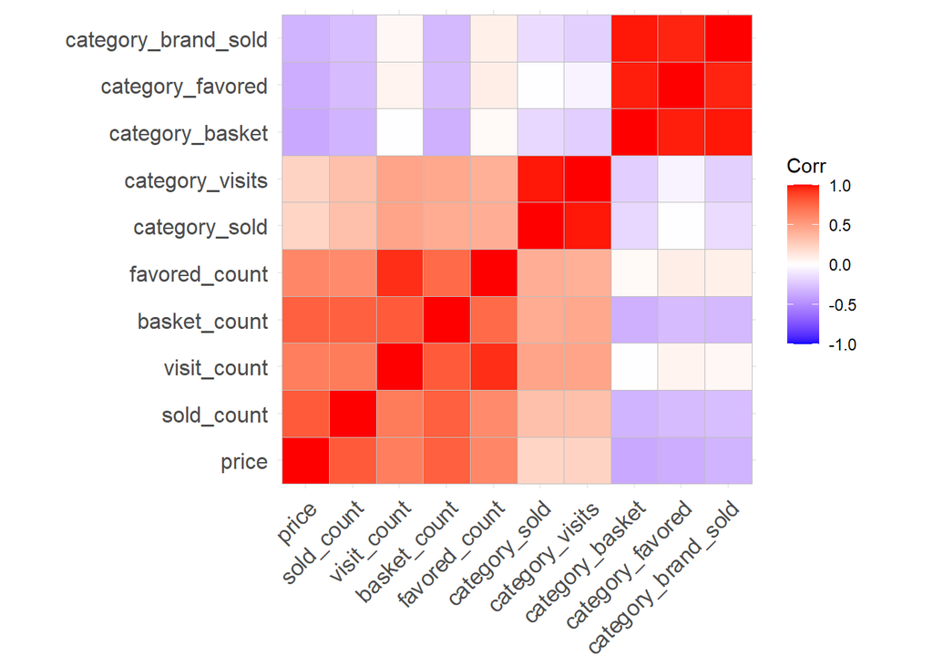

```r
ggcorrplot(cor(mont[,3:12]) )
```

For ‘Mont product’, ‘price’ and ‘basket_count’ variables are the most correlated variables for the sold_count.

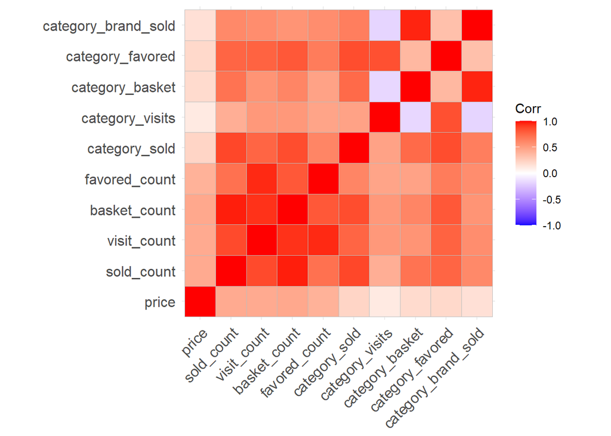

```r
ggcorrplot(cor(bikini_1[,3:12]) )
```

For ‘Bikini_1 product’, ‘basket_count’ and ‘category_sold’ variables are the most correlated variables for the sold_count.

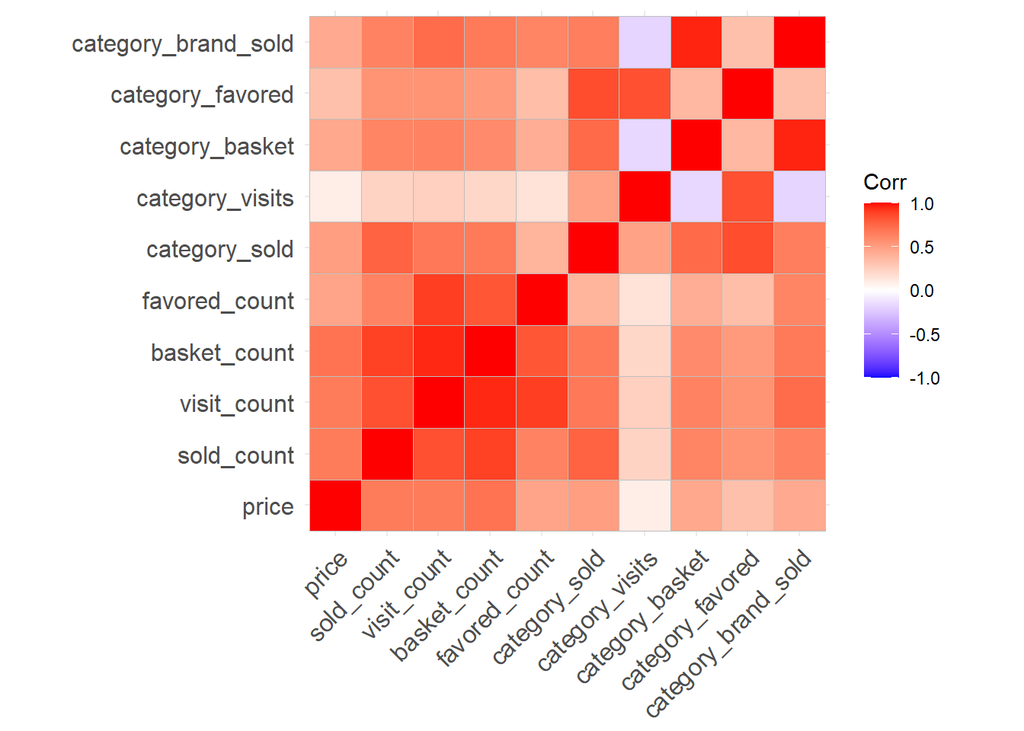

```r
ggcorrplot(cor(bikini_2[,3:12]) )
```

For ‘Bikini_2 product’, ‘visit_count’ and ‘basket_count’ variables are the most correlated variables for the sold_count.

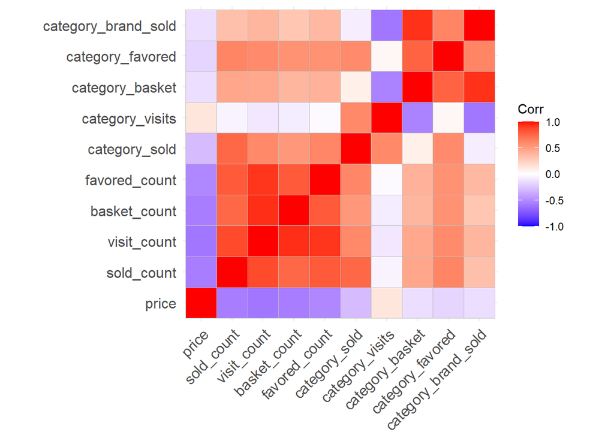

```r
ggcorrplot(cor(tayt[,3:12]) )
```

For ‘Tayt product’, ‘price’ and ‘favored_count’ variables are the most correlated variables for the sold_count.

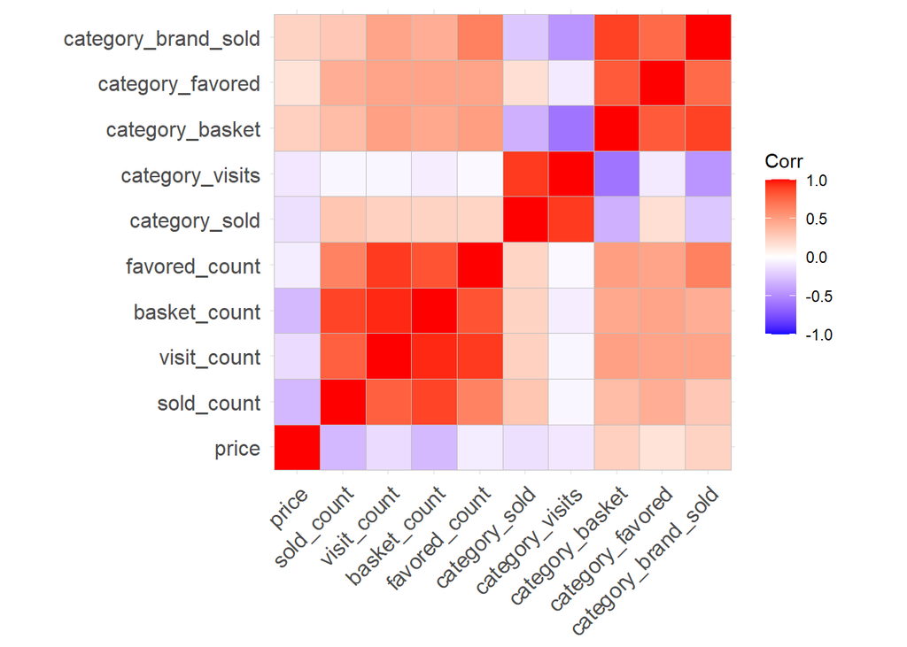

```r
ggcorrplot(cor(kulaklık[,3:12]) )
```

For ‘Kulaklık product’, ‘price’ and ‘basket_count’ variables are the most correlated variables for the sold_count.

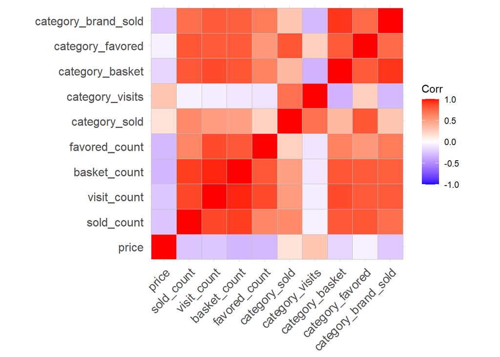

```r
ggcorrplot(cor(supurge[,3:12]) )
```

For ‘Süpürge product’, ‘price’ and ‘visit_count’ variables are the most correlated variables for the sold_count.

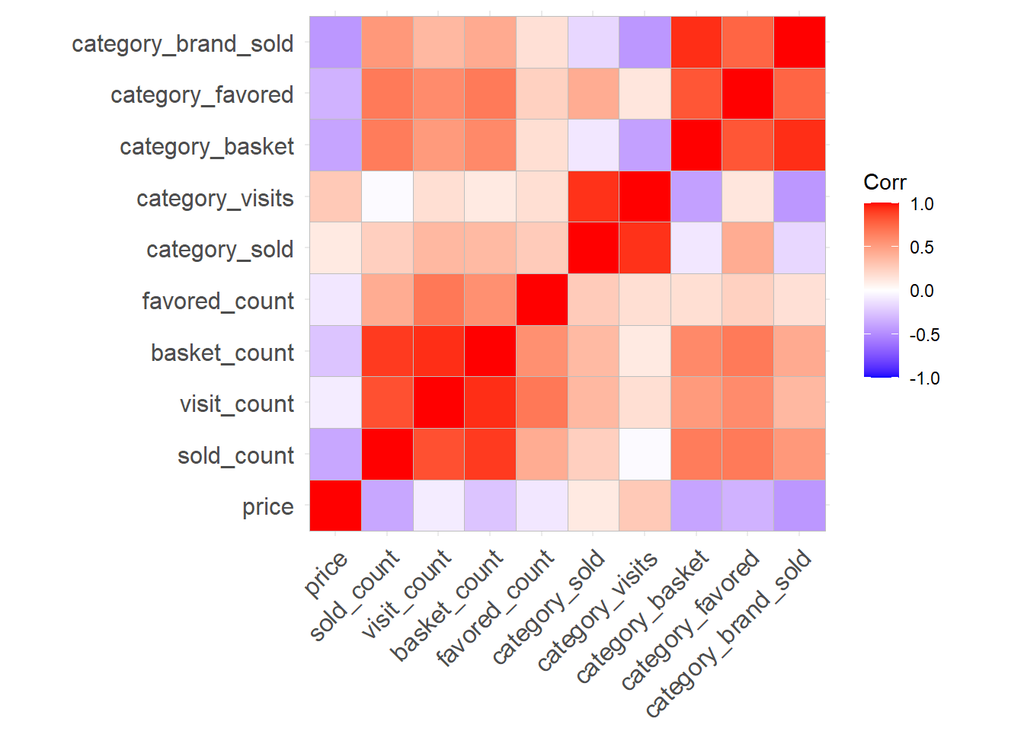

```r
ggcorrplot(cor(yuz_temizleyicisi[,3:12]) )
```

For ‘Yüz Temizleyicisi product’, ‘price’ and ‘basket_count’ variables are the most correlated variables for the sold_count.

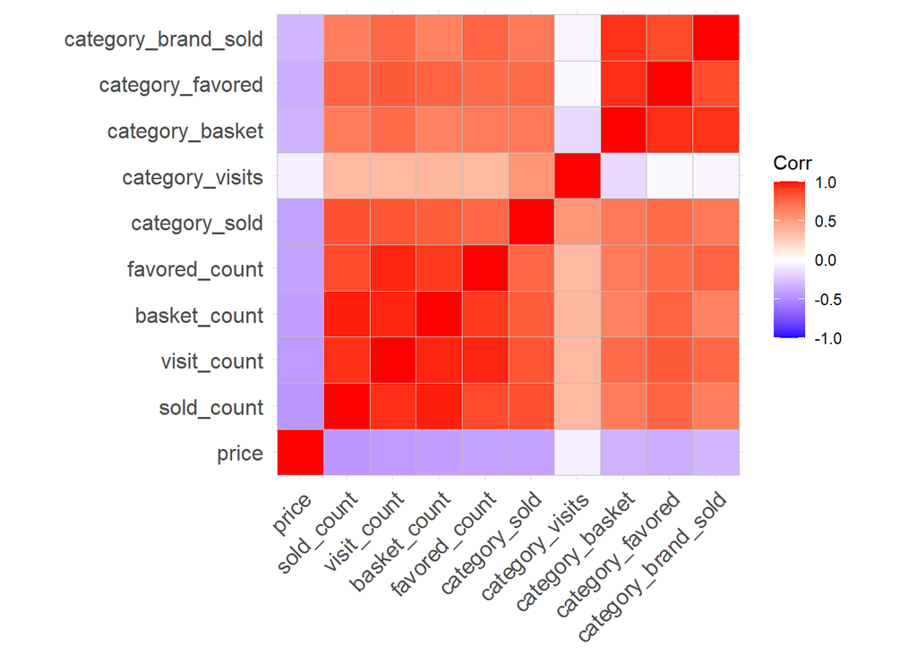

```r
ggcorrplot(cor(mendil[,3:12]) )
```

For ‘Mendil product’, ‘price’ and ‘visit_count’ variables are the most correlated variables for the sold_count.

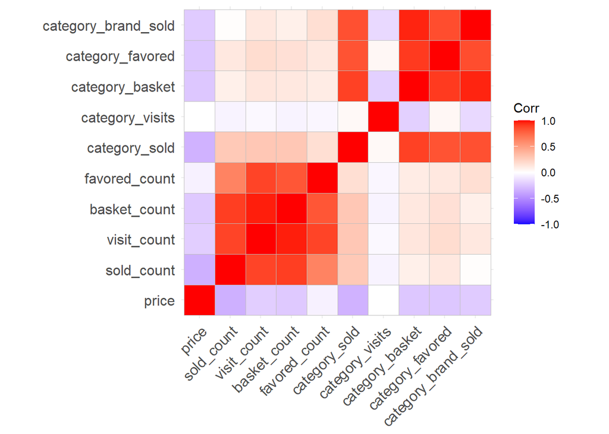

```r
ggcorrplot(cor(dis_fircasi[,3:12]) )
```

For ‘Diş Fırçası product’, ‘price’ and ‘visit_count’ variables are the most correlated variables for the sold_count.

## Using the potential regressors in the selected ARIMA models

In this section, the best ARIMA model in terms of AIC will be compared with ARIMAX models. ARIMAX models will be built with most 2 positively or negatively correlated external regressors for each product. Functin for comparing the two models is below:

```r
ARIMAX_function <- function(X, regressor_1,regressor_2,p,d,q){
  X <- X %>% map_df(rev)
  df_train <- X[!(X$event_date >= "2021-05-25"),]
  df_test <- X[!(X$event_date < "2021-05-25"),]
  df_new <- ts(df_train$sold_count,frequency=7)
  df_additive <- decompose(df_new,type="additive")
  df_deseasoned_detrended <- df_new-df_additive$seasonal-df_additive$trend
  df_deseasoned_detrended[1:3] <- mean(df_deseasoned_detrended[4:6])
  df_deseasoned_detrended[113:115] <- mean(df_deseasoned_detrended[110:112])
  forecasted_seasonal = (df_additive$seasonal)[108:114]
  forecasted_trend = rep(mean(tail(df_additive$trend[!is.na(df_additive$trend)],2)),7)

  pf_reg1<-forecast(regressor_1,h=7)$mean[1]
  pf_reg2<-forecast(regressor_2,h=7)$mean[1]
  newxreg <- as.matrix(cbind(pf_reg1, pf_reg2))
  matrix = cbind(regressor_1[1:115],regressor_2[1:115])

  old_model=arima(df_deseasoned_detrended,order=c(p,d,q))
  model_forecast_old <- predict(old_model, n.ahead = 7)$pred
  #print(model_forecast_old)
  print(AIC(old_model))

  fitted_arimax=auto.arima(df_deseasoned_detrended,xreg=matrix)
  model_forecast_new <- forecast(fitted_arimax,xreg=newxreg)$mean[1]
  model_forecast_new<- rep(model_forecast_new,7)
  #print(model_forecast_new)
  print(AIC(fitted_arimax))



  new_restored <- forecasted_seasonal+forecasted_trend+model_forecast_new
  old_restored <- forecasted_seasonal+forecasted_trend+model_forecast_old



  error_new=X$sold_count[116:122]-new_restored
  error_old=X$sold_count[116:122]-old_restored

  mean=mean(X$sold_count)
  MAD_2=sum(abs(error_old))/length(X$sold_count)
  WMAPE_old=MAD_2/mean
  print(WMAPE_old)

  mean=mean(X$sold_count)
  MAD_1=sum(abs(error_new))/length(X$sold_count)
  WMAPE_new=MAD_1/mean
  print(WMAPE_new)
}
```

For the ‘Mont Product’:

```r
ARIMAX_function(mont,mont$price,mont$basket_count,1,0,2)
```

```
## [1] 149.6967
```

```
## [1] 143.2324
## [1] 0.1846941
## [1] 0.2353858
```

Here we see that arima model has 149 AIC and arimax model has 143 AIC. New model is slightly better. In terms of prediction , the new model suffers much more than old model. we see that old model’s wmape is around 18 pct and new model’s wmape is around 23 pct. This may be occured from pointforecasting the regressor values since it accumulates the error.

For the ‘Bikini_1 Product’:

```r
ARIMAX_function(bikini_1,bikini_1$basket_count,bikini_1$category_sold,1,0,3)
```

```
## [1] 951.8343
```

```
## [1] 944.04
## [1] 0.08170744
## [1] 0.09390802
```

Here we see that arima model has 951 AIC and arimax model has 944 AIC. New model is slightly better. In terms of prediction , the new model suffers much more than old model. we see that old model’s wmape is around 8 pct and new model’s wmape is around 9 pct. This may be occured from pointforecasting the regressor values since it accumulates the error same as in previous one.

For the ‘Bikini_2 Product’:

```r
ARIMAX_function(bikini_2,bikini_2$visit_count,bikini_2$basket_count,1,0,3)
```

```
## [1] 797.075
```

```
## [1] 845.5657
## [1] 0.01756959
## [1] 0.01893382
```

Here we see that arima model has 797 AIC and arimax model has 845 AIC. New model is slightly worse. In terms of prediction , the new model suffers more than old model. we see that old model’s wmape is around 1.7 pct and new model’s wmape is around 1.8 pct. This may be occured from pointforecasting the regressor values since it accumulates the error.

For the ‘Tayt Product’:

```r
ARIMAX_function(tayt,tayt$price,tayt$favored_count,1,0,3)
```

```
## [1] 1613.902
```

```
## [1] 1639.689
## [1] 0.01965264
## [1] 0.01470704
```

Here we see that arima model has 1613 AIC and arimax model has 1639 AIC. New model is slightly worse. In terms of prediction , the new model predicts much better than old model. we see that old model’s wmape is around 1.9 pct and new model’s wmape is around 1.4 pct.

For the ‘Kulaklık Product’:

```r
ARIMAX_function(kulaklık,kulaklık$price,kulaklık$basket_count,1,0,3)
```

```
## [1] 1370.454
```

```
## [1] 1390.838
## [1] 0.02519358
## [1] 0.01110617
```

Here we see that arima model has 1370 AIC and arimax model has 1390 AIC. New model is slightly worse. In terms of prediction , the new model predicts much better than old model. we see that old model’s wmape is around 2.5 pct and new model’s wmape is around 1.1 pct.

For the ‘Süpürge Product’:

```r
ARIMAX_function(supurge,supurge$price,supurge$visit_count,1,0,2)
```

```
## [1] 753.9106
```

```
## [1] 769.2982
## [1] 0.01188456
## [1] 0.01182937
```

Here we see that arima model has 753 AIC and arimax model has 769 AIC. New model is slightly worse. In terms of prediction , the new model predicts slightly better than old model. we see that old model’s wmape is around 1.1 pct and new model’s wmape is around 1.1 pct.

For the ‘Yüz Temizleyicisi Product’:

```r
ARIMAX_function(yuz_temizleyicisi,yuz_temizleyicisi$price,yuz_temizleyicisi$basket_count,1,0,3)
```

```
## [1] 1038.381
```

```
## [1] 1066.679
## [1] 0.01478238
## [1] 0.01235416
```

Here we see that arima model has 1038 AIC and arimax model has 1066 AIC. New model is slightly worse. In terms of prediction , the new model predicts much better than old model. we see that old model’s wmape is around 1.4 pct and new model’s wmape is around 1.2 pct.

For the ‘Mendil Product’:

```r
ARIMAX_function(mendil,mendil$price,mendil$visit_count,1,0,3)
```

```
## [1] 1464.796
```

```
## [1] 1479.522
## [1] 0.03463817
## [1] 0.03178024
```

For the ‘Diş Fırçası Product’:

```r
ARIMAX_function(dis_fircasi,dis_fircasi$price,dis_fircasi$visit_count,1,1,2)
```

```
## [1] 1172.028
```

```
## [1] 1175.958
## [1] 0.01759382
## [1] 0.0157276
```

Here we see that arima model has 1172 AIC and arimax model has 1175 AIC. New model is slightly worse. In terms of prediction , the new model predicts better than old model. we see that old model’s wmape is around 1.7 pct and new model’s wmape is around 1.5 pct.